# PostgreSQL

## Borrado de datos

```python
%alias dropdb docker exec -i postgres_container dropdb -U postgres
%alias createdb docker exec -i postgres_container createdb -U postgres
```

```python
dropdb black
```

```python
createdb black
```

```python
%load_ext sql
```

```python
%sql postgresql://postgres:postgres@localhost/black
```

# Carga de datos en Pandas

Partimos de los datos normalizados en fichero Excel. Leemos cada hoja del fichero Excel en un DataFrame de Pandas distinto

```python
import pandas as pd
```

```python
df_mov = pd.read_excel("./data/black.xlsx", sheet_name= "Movimientos", engine='openpyxl')
df_miembros = pd.read_excel("./data/black.xlsx", sheet_name= "Miembros", engine='openpyxl')
```

Se realiza una pequeña comprobación para verificar que no hay datos duplicados

```python
df_mov.head(5)
```

|  | id_miembro | fecha | hora | minuto | importe | comercio | actividad_completa | actividad |
| --- | --- | --- | --- | --- | --- | --- | --- | --- |
| 0 | 77 | 2006-04-17 | 11 | 40 | 44.56 | FCIA TORRES MU¬OZ | FARMACIAS | SALUD |
| 1 | 15 | 2010-09-11 | 14 | 26 | 67.56 | E.S.VEGONES DER | C.A.M.P.S.A. | COCHE |
| 2 | 29 | 2003-01-24 | 14 | 15 | 191.00 | EL CORTE INGLES | EL CORTE INGLES | COMPRA BIENES |
| 3 | 74 | 2007-05-10 | 15 | 2 | 599.20 | VIAJES ECI | EL CORTE INGLES | COMPRA BIENES |
| 4 | 77 | 2010-12-18 | 14 | 35 | 3.65 | PK VELAZQUEZ JORGE JUAN | GARAJES Y APARCAMIENTOS | COCHE |

```python
(df_mov.groupby(['fecha', 'id_miembro', 'hora', 'minuto', 'comercio', 'importe']).size() > 1).sum()
```

```
0
```

```python
df_mov.query('id_miembro == 77 and hora == 11 and minuto == 40')
```

|  | id_miembro | fecha | hora | minuto | importe | comercio | actividad_completa | actividad |
| --- | --- | --- | --- | --- | --- | --- | --- | --- |
| 0 | 77 | 2006-04-17 | 11 | 40 | 44.56 | FCIA TORRES MU¬OZ | FARMACIAS | SALUD |

Perfecto ;-)

## Creacción de tablas

Para almacenar la información se van a crear 2 tablas, una con movimientos y otra con los miembros de la organización que han realizado el movimiento.  
Las 2 tablas están relacionadas por el campo id_miembro (se llama igual en ambas tablas)

Adicionalmente se va a utilizar una secuencia que nos va a permitir tener una PK única para la tabla de movimientos

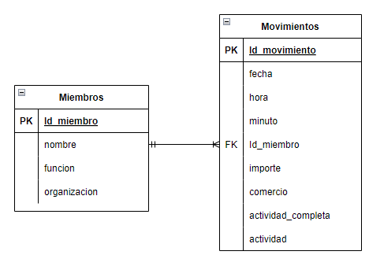

La siguiente instrucción fallará la primera vez que se ejecuta!

```python
%sql DROP TABLE movimientos
%sql DROP TABLE miembros
%sql DROP SEQUENCE seq_mov_id;
```

```
 * postgresql://postgres:***@localhost/black
(psycopg2.errors.UndefinedTable) table "movimientos" does not exist

[SQL: DROP TABLE movimientos]
(Background on this error at: https://sqlalche.me/e/14/f405)
 * postgresql://postgres:***@localhost/black
(psycopg2.errors.UndefinedTable) table "miembros" does not exist

[SQL: DROP TABLE miembros]
(Background on this error at: https://sqlalche.me/e/14/f405)
 * postgresql://postgres:***@localhost/black
(psycopg2.errors.UndefinedTable) sequence "seq_mov_id" does not exist

[SQL: DROP SEQUENCE seq_mov_id;]
(Background on this error at: https://sqlalche.me/e/14/f405)
```

```python
%sql CREATE SEQUENCE seq_mov_id;
```

```
 * postgresql://postgres:***@localhost/black
Done.
```

```
[]
```

```python
%%sql
CREATE TABLE miembros (
    id_miembro      int not null PRIMARY KEY,
    nombre         varchar(200),
    funcion        varchar(40),
    organizacion   varchar(200),
    CONSTRAINT pk_miembros UNIQUE(id_miembro)
);
```

```
 * postgresql://postgres:***@localhost/black
Done.
```

```
[]
```

```python
%%sql
CREATE TABLE movimientos (
    id_movimiento   int not null default nextval('seq_mov_id'),
    fecha           date not null,
    hora            int not null,
    minuto          int not null,
    id_miembro      int not null REFERENCES miembros(id_miembro),
    importe         decimal not null,
    comercio        varchar(200),
    actividad_completa varchar(200),
    actividad       varchar(100),
    CONSTRAINT pk_movimientos UNIQUE(id_movimiento)
);
```

```
 * postgresql://postgres:***@localhost/black
Done.
```

```
[]
```

## Exportación de los datos a PostgreSQL

Para exportar los datos a la base de datos, vamos a aprovechar una funcionalidad que nos ofrece Pandas, de exportación de datos a una base de datos relacional.

En este caso hemos creado el esquema previamente, pero podríamos no haberlo hecho (parámetro **if_exists**)

```python
from sqlalchemy import create_engine
```

```python
engine = create_engine('postgresql://postgres:postgres@localhost:5432/black')
```

```python
df_miembros.head(10)
```

|  | id_miembro | nombre | funcion | organizacion |
| --- | --- | --- | --- | --- |
| 0 | 1 | Alberto Recarte García Andrade | concejal | Partido Popular |
| 1 | 2 | Alejandro Couceiro Ojeda | concejal | CEIM |
| 2 | 83 | Ángel Eugenio Gómez del Pulgar Perales | concejal | PSOE |
| 3 | 3 | Angel Rizaldos González | concejal | Izquierda Unida |
| 4 | 4 | Antonio Cámara Eguinoa | concejal | Partido Popular |
| 5 | 5 | Antonio Rey de Viñas Sánchez-Majestad | concejal | CC OO |
| 6 | 6 | Antonio Romero Lázaro | concejal | PSOE |
| 7 | 7 | Arturo Luis Fernández Álvarez | concejal | CEIM |
| 8 | 8 | Beltrán Gutiérrez Moliner | concejal | Partido Popular |
| 9 | 12 | Cándido Cerón Escudero | concejal | Partido Popular |

```python
df_miembros.to_sql('miembros', engine, if_exists = 'append', index = False)
```

```
83
```

```python
df_mov.to_sql('movimientos', engine, if_exists = 'append', index = False)
```

```
624
```

Fijate que las columnas en Pandas y en la tabla tienen que ser exactamente las mismas y llamarse igual!

PostgreSQL pone automáticamente el nombre de las columnas en minúscula a no ser que cuando crees la tabla pogas el nombre de las columnas entrecomillado.

# Consultando información

Hacemos unas querys previas para vericar que todo ha ido bien

```python
%%sql
select count(*)
from movimientos
```

```
 * postgresql://postgres:***@localhost/black
1 rows affected.
```

| count |
| --- |
| 7624 |

```python
%%sql
select count(*)
from miembros
```

```
 * postgresql://postgres:***@localhost/black
1 rows affected.
```

| count |
| --- |
| 83 |

```python
%%sql
select count(distinct comercio || actividad || actividad_completa)
from movimientos
where comercio is not null
```

```
 * postgresql://postgres:***@localhost/black
1 rows affected.
```

| count |
| --- |
| 3204 |

```python
%%sql
select *
from movimientos
order by importe desc
limit 10
```

```
 * postgresql://postgres:***@localhost/black
10 rows affected.
```

| id_movimiento | fecha | hora | minuto | id_miembro | importe | comercio | actividad_completa | actividad |
| --- | --- | --- | --- | --- | --- | --- | --- | --- |
| 7254 | 2007-11-28 | 9 | 57 | 14 | 12000.0 | None | AGENCIAS BANCARIAS(ANTICIPO VENTANILLA) | BANCO |
| 3793 | 2007-12-19 | 14 | 42 | 74 | 9424.08 | None | AGENCIAS BANCARIAS(ANTICIPO VENTANILLA) | BANCO |
| 5022 | 2008-10-23 | 11 | 37 | 14 | 9000.0 | None | AGENCIAS BANCARIAS(ANTICIPO VENTANILLA) | BANCO |
| 135 | 2006-11-29 | 9 | 13 | 14 | 8000.0 | None | AGENCIAS BANCARIAS(ANTICIPO VENTANILLA) | BANCO |
| 3171 | 2006-12-26 | 15 | 41 | 61 | 6397.31 | VIAJES ECI | EL CORTE INGLES | COMPRA BIENES |
| 974 | 2007-11-30 | 13 | 6 | 72 | 6375.0 | YUSTY | CONFECCION TEXTIL EN GENERAL | ROPA |
| 5106 | 2006-08-13 | 12 | 16 | 11 | 6198.02 | HOTEL BARROSA PARK | HOTELES 4 Y 5 ESTRELLAS,BALNEARIOS,CAMPI | HOTEL |
| 878 | 2006-08-13 | 17 | 24 | 59 | 5763.1 | None | BRITISH AIRWAYS - BRITISH A | AVION |
| 5271 | 2005-07-31 | 15 | 35 | 50 | 5403.97 | NAUTICA BAUTISTA | AUTOM.Y MOTOCICLETAS ( VENTAS Y REPARAC) | COCHE |
| 6076 | 2004-12-06 | 9 | 47 | 14 | 5390.0 | None | AGENCIAS BANCARIAS(ANTICIPO VENTANILLA) | BANCO |

### Los 10 movimientos mas caros por actividad

```python
%%sql
select nombre, fecha, actividad_completa, importe
from movimientos mov
    inner join miembros mi on (mov.id_miembro = mi.id_miembro)
where actividad = 'HOGAR'
order by importe desc
limit 10
```

```
 * postgresql://postgres:***@localhost/black
10 rows affected.
```

| nombre | fecha | actividad_completa | importe |
| --- | --- | --- | --- |
| Miguel Ángel Araujo Serrano | 2007-10-14 | MUEBLES,ANTIGUEDADES Y GALERIAS DE ARTE | 2150.0 |
| Mariano Pérez Claver | 2005-12-16 | FLORES Y PLANTAS | 1908.19 |
| Domingo Navalmoral Sánchez | 2004-01-09 | TAPICERIAS,ALFOMBRAS | 1800.0 |
| Ramón Ferraz Ricarte | 2008-07-06 | MUEBLES,ANTIGUEDADES Y GALERIAS DE ARTE | 1281.31 |
| Miguel Ángel Araujo Serrano | 2011-03-10 | MUEBLES DE COCINA | 1231.0 |
| Francisco Baquero Noriega | 2007-04-20 | MUEBLES,ANTIGUEDADES Y GALERIAS DE ARTE | 1188.9 |
| Francisco Baquero Noriega | 2006-11-03 | MUEBLES,ANTIGUEDADES Y GALERIAS DE ARTE | 1090.0 |
| Jesús Pedroche Nieto | 2011-05-24 | MUEBLES,ANTIGUEDADES Y GALERIAS DE ARTE | 1000.0 |
| Pedro Bugidos Garay | 2006-02-07 | MUEBLES,ANTIGUEDADES Y GALERIAS DE ARTE | 1000.0 |
| Ricardo Romero de Tejada y Picatoste | 2009-04-06 | ELECTRODOMESTICOS,EQUIPOS ELECTRICOS | 1000.0 |

### Los 10 movimientos mas caros

```python
%%sql
select nombre, fecha, actividad_completa, importe
from movimientos mov
    inner join miembros mi on (mov.id_miembro = mi.id_miembro)
order by importe desc
limit 10
```

```
 * postgresql://postgres:***@localhost/black
10 rows affected.
```

| nombre | fecha | actividad_completa | importe |
| --- | --- | --- | --- |
| Enrique de la Torre Martínez | 2007-11-28 | AGENCIAS BANCARIAS(ANTICIPO VENTANILLA) | 12000.0 |
| Ramón Ferraz Ricarte | 2007-12-19 | AGENCIAS BANCARIAS(ANTICIPO VENTANILLA) | 9424.08 |
| Enrique de la Torre Martínez | 2008-10-23 | AGENCIAS BANCARIAS(ANTICIPO VENTANILLA) | 9000.0 |
| Enrique de la Torre Martínez | 2006-11-29 | AGENCIAS BANCARIAS(ANTICIPO VENTANILLA) | 8000.0 |
| Miguel Blesa de la Parra | 2006-12-26 | EL CORTE INGLES | 6397.31 |
| Rafael Spottorno Díaz Caro | 2007-11-30 | CONFECCION TEXTIL EN GENERAL | 6375.0 |
| Carmen Contreras Gómez | 2006-08-13 | HOTELES 4 Y 5 ESTRELLAS,BALNEARIOS,CAMPI | 6198.02 |
| Matías Amat Roca | 2006-08-13 | BRITISH AIRWAYS - BRITISH A | 5763.1 |
| Juan Manuel Astorqui Portera | 2005-07-31 | AUTOM.Y MOTOCICLETAS ( VENTAS Y REPARAC) | 5403.97 |
| Enrique de la Torre Martínez | 2004-12-06 | AGENCIAS BANCARIAS(ANTICIPO VENTANILLA) | 5390.0 |

### Los movimientos de una persona concreta (ordenados por importe)

```python
%%sql
select nombre, fecha, actividad_completa, importe
from movimientos mov
    inner join miembros mi on (mov.id_miembro = mi.id_miembro)
where nombre = 'Mariano Pérez Claver'
order by importe desc
limit 10
```

```
 * postgresql://postgres:***@localhost/black
10 rows affected.
```

| nombre | fecha | actividad_completa | importe |
| --- | --- | --- | --- |
| Mariano Pérez Claver | 2006-01-12 | EL CORTE INGLES | 2831.84 |
| Mariano Pérez Claver | 2004-11-03 | AGENCIAS DE VIAJES | 2805.26 |
| Mariano Pérez Claver | 2005-12-16 | FLORES Y PLANTAS | 1908.19 |
| Mariano Pérez Claver | 2005-07-13 | HOSPITALES,SANATORIOS Y CONSULTAS MEDIC | 1863.0 |
| Mariano Pérez Claver | 2007-12-28 | FLORES Y PLANTAS | 950.4 |
| Mariano Pérez Claver | 2003-01-13 | ELECTRODOMESTICOS,EQUIPOS ELECTRICOS | 775.0 |
| Mariano Pérez Claver | 2006-09-01 | CONFECCION TEXTIL EN GENERAL | 694.0 |
| Mariano Pérez Claver | 2003-07-28 | EL CORTE INGLES | 621.0 |
| Mariano Pérez Claver | 2010-05-14 | CAJEROS AUTOMATICOS | 600.0 |
| Mariano Pérez Claver | 2008-07-11 | CAJEROS AUTOMATICOS | 600.0 |

### Las 10 personas que mas han gastado

```python
%%sql
select nombre, sum(importe) as importe
from movimientos mov
    inner join miembros mi on (mov.id_miembro = mi.id_miembro)
group by 1
order by 2 desc
limit 10
```

```
 * postgresql://postgres:***@localhost/black
10 rows affected.
```

| nombre | importe |
| --- | --- |
| Enrique de la Torre Martínez | 58826.28 |
| José Antonio Moral Santín | 52447.07 |
| Ramón Ferraz Ricarte | 45371.52 |
| Miguel Blesa de la Parra | 40298.84 |
| Ildefonso José Sánchez Barcoj | 39437.99 |
| Juan Manuel Astorqui Portera | 36627.89 |
| Francisco Baquero Noriega | 35256.67 |
| Matías Amat Roca | 33434.74 |
| Carmen Contreras Gómez | 31556.45 |
| Estanislao Rodríguez-Ponga Salamanca | 29350.65 |

### Importes de una persona agrupados por actividad

```python
%%sql
select nombre, actividad, sum(importe) as importe
from movimientos mov
    inner join miembros mi on (mov.id_miembro = mi.id_miembro)
where nombre = 'Mariano Pérez Claver'
group by 1,2
order by 3 desc
```

```
 * postgresql://postgres:***@localhost/black
18 rows affected.
```

| nombre | actividad | importe |
| --- | --- | --- |
| Mariano Pérez Claver | COMPRA BIENES | 5344.36 |
| Mariano Pérez Claver | HOGAR | 3633.59 |
| Mariano Pérez Claver | RESTAURANTE | 3573.79 |
| Mariano Pérez Claver | VIAJE | 3013.95 |
| Mariano Pérez Claver | CA$H | 2400.0 |
| Mariano Pérez Claver | HOTEL | 2020.11 |
| Mariano Pérez Claver | SALUD | 1863.0 |
| Mariano Pérez Claver | ROPA | 1147.34 |
| Mariano Pérez Claver | COCHE | 1056.19 |
| Mariano Pérez Claver | REGALOS | 850.0 |
| Mariano Pérez Claver | COMPRA BIENES LUJO | 669.02 |
| Mariano Pérez Claver | DUTYFREE | 186.81 |
| Mariano Pérez Claver | MISC | 137.04 |
| Mariano Pérez Claver | IMAGEN | 136.94 |
| Mariano Pérez Claver | SALIDAS | 120.44 |
| Mariano Pérez Claver | SUPERMERCADO | 71.59 |
| Mariano Pérez Claver | TREN | 66.59 |
| Mariano Pérez Claver | AVION | -163.22 |

### ¿Quién se gasta más, los concejales o los directivos?

```python
%%sql
select funcion, sum(importe) as importe
from movimientos mov
    inner join miembros mi on (mov.id_miembro = mi.id_miembro)
group by 1
order by 2 desc
```

```
 * postgresql://postgres:***@localhost/black
2 rows affected.
```

| funcion | importe |
| --- | --- |
| concejal | 706991.27 |
| directivo | 443740.82 |

### ¿Qué organización se gasta más?

```python
%%sql
select organizacion, sum(importe) as importe
from movimientos mov
    inner join miembros mi on (mov.id_miembro = mi.id_miembro)
where organizacion is not null
group by 1
order by 2 desc
```

```
 * postgresql://postgres:***@localhost/black
10 rows affected.
```

| organizacion | importe |
| --- | --- |
| Partido Popular | 281008.13 |
| PSOE | 147128.03 |
| Izquierda Unida | 89149.22 |
| CC OO | 86368.54 |
| UGT | 35198.35 |
| Conf. de Cuadros | 21821.12 |
| CEIM | 13127.54 |
| Comisión de Control | 12384.31 |
| CEOE | 11650.0 |
| Patronal (Unipyme) | 9156.03 |

### ¿Qué comercio es más popular entre los miembros?

```python
%%sql
select comercio, count(distinct mov.id_miembro) as numero_miembros
from movimientos mov
    inner join miembros mi on (mov.id_miembro = mi.id_miembro)
where comercio is not null
group by 1
order by 2 desc
limit 5
```

```
 * postgresql://postgres:***@localhost/black
5 rows affected.
```

| comercio | numero_miembros |
| --- | --- |
| EL CORTE INGLES | 49 |
| IBERIA | 29 |
| RENFE 001 | 28 |
| EL CORTE INGLES S.A. | 26 |
| PARKING EGUISA C/SEVILLA | 16 |